# histo2prll_mb220_err_

Michael Berbach

2023-02-21

### Question 1

I modified the pipeline:

```r
# time zgrep "TAVG" /stat129/*.gz | cut -d"," -f 4 | sort -n | uniq -c | awk '{print $1","$2}' > tAVG215mb.csv
#
#
# to
#
#
# time ls /stat129/*.gz | parallel 'zgrep "TAVG" {} | cut -d"," -f 4 | sort -n | uniq -c | awk "{print \$1\",\"$2}"' > tAVG215mb.csv
```

The idea was that ls would feed each file into the pipeline, handling each file as a chunk that would then be written into the csv file. However there is some sort of logic error I am still working out. Initially it was getting the awk command to work within the ’’, since that is typically its own notation. It required proper placement of to get it to make something reasonable. However the file output is still different that the original tAVG file, so more testing is necessary.

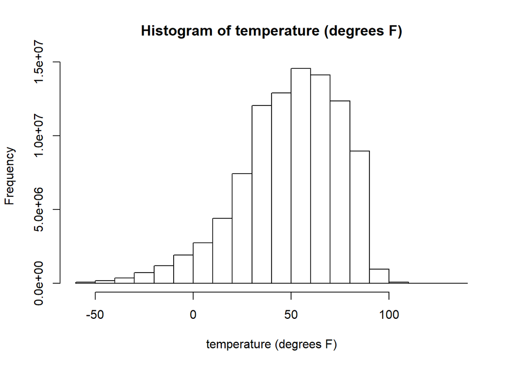

```r
hist_from_count = function(countfile, upper = 140, lower = -60, varname = "temperature (degrees F)", ...)
{
    # Plot a histogram of the temperature for our weather data.

    d = read.table(countfile, row.names = NULL, sep = ",")
    colnames(d) = c("count", "value")
    d[["count"]] = as.numeric(d[["count"]])

    # Convert from tenths of degree celsius to Fahrenheit
    d[["value"]] = (d[["value"]]/10 * (9/5)) + 32

    # Drop outliers
    d = d[lower < d[["value"]] & d[["value"]] < upper, ]

    # general logic for creating a histogram from output of bash table:
    #        sort | uniq --count > counts.txt
    result = hist(d[["value"]], plot = FALSE, ...)
    d[["bin"]] = cut(d[["value"]], breaks = result[["breaks"]])
    counts = tapply(d[["count"]], d[["bin"]], sum)
    counts[is.na(counts)] = 0

    result[["counts"]] = counts
    result[["density"]] = counts / sum(counts)
    result[["xname"]] = varname
    result
}


# Example if you've saved resulting table as temp_counts.txt
h = hist_from_count("C:\\Users\\mikeb\\Documents\\Stat129\\tAVG220Prll.csv")
plot(h)
```

After looking at the histogram though, it appears to take a similar shape as the original file, but shows a greater spread? Really not sure what the deal is. I also noticed that RMD is not showing the exact notation, taking out the slashes and hyphens, so I’ll have to go back and probably turn it into r-code as a comment.

I did go back and turn it into R-code comments and that seems to preserve it better.

### Question 2

Despite the aforementioned, the parallel process was 3.8x faster than the non-parallel process. I’ll include the time stamps below

*Original time*

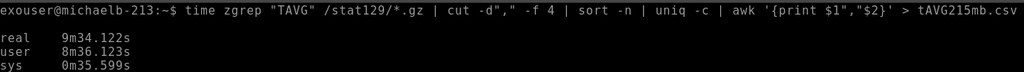

*Time in parallel*

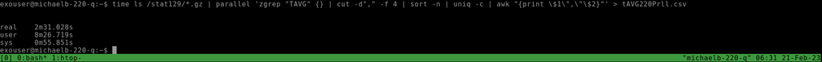

that is about 2 mins and 30 seconds if you are having a hard time seeing that last picture.

### Question 3

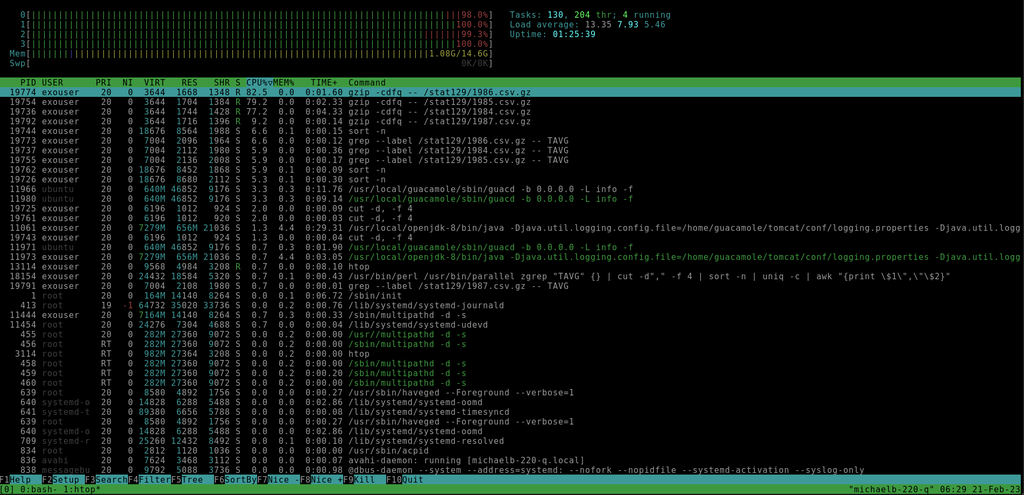

Screen cap of best htop

This is part of why I initially thought the idea would work, since each core appears to be moving chunks through a pipeline. Though I only see three sort commands and three cut commands so not sure what the deal is there. I suppose it did work in some capacity, but I’m pretty sure the data I pulled is not quite right.

I’ll add a closeup of the exouser processes as well as another cap from another run.

*This is a close up of the exouser processes*

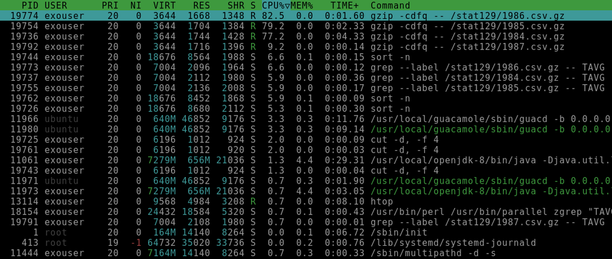

*This run had a logic error in the awk command*

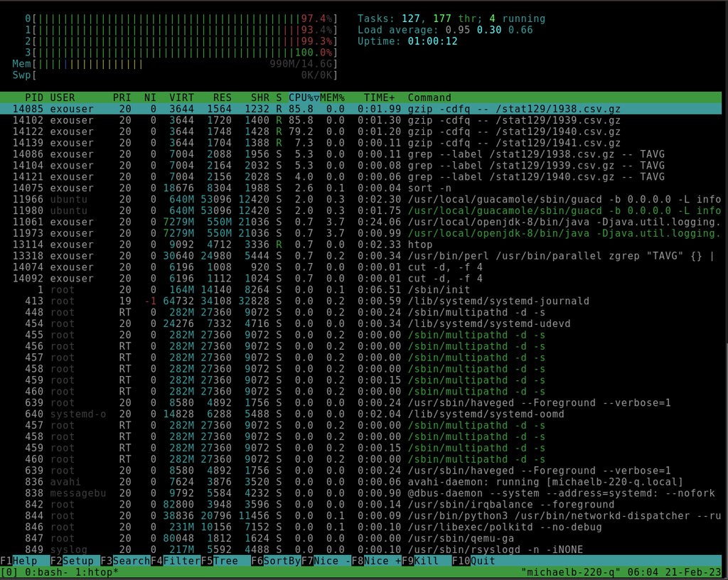